# Classification

## Default Dataset

```python
import pandas as pd
import numpy as np
```

```python
Default=pd.read_csv('Default.csv',index_col=0)
Default.head()
```

|  | default | student | balance | income |
| --- | --- | --- | --- | --- |
| 1 | No | No | 729.526495 | 44361.625074 |
| 2 | No | Yes | 817.180407 | 12106.134700 |
| 3 | No | No | 1073.549164 | 31767.138947 |
| 4 | No | No | 529.250605 | 35704.493935 |
| 5 | No | No | 785.655883 | 38463.495879 |

## Boxplot

A boxplot is a standardized way of displaying the distribution of data based on a five number summary (“minimum”, first quartile (Q1), median, third quartile (Q3), and “maximum”). It can tell you about your outliers and what their values are. For more information on boxplot, you can refer to https://towardsdatascience.com/understanding-boxplots-5e2df7bcbd51

```python
import matplotlib.pyplot as plt
```

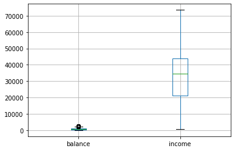

```python
Default.boxplot(column=['balance','income'])
plt.show()
```

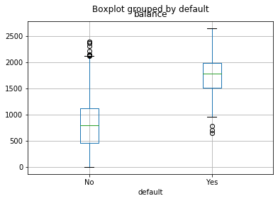

```python
Default.boxplot(column='balance',by='default')
plt.show()
```

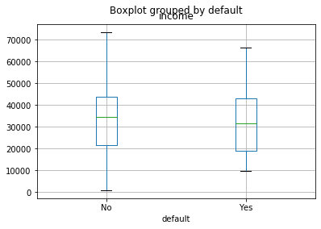

```python
Default.boxplot(column='income',by='default')
plt.show()
```

## Logistic Regression

```python
import statsmodels.formula.api as smf
```

To perform logisitic regression, one has to transform the reponse variable to binary variable

```python
Default['default01'] = (Default.default == 'Yes').astype(int)
Default.head()
```

|  | default | student | balance | income | default01 |
| --- | --- | --- | --- | --- | --- |
| 1 | No | No | 729.526495 | 44361.625074 | 0 |
| 2 | No | Yes | 817.180407 | 12106.134700 | 0 |
| 3 | No | No | 1073.549164 | 31767.138947 | 0 |
| 4 | No | No | 529.250605 | 35704.493935 | 0 |
| 5 | No | No | 785.655883 | 38463.495879 | 0 |

```python
results = smf.logit('default01 ~ balance', data=Default).fit()
print(results.summary())
```

```
Optimization terminated successfully.
         Current function value: 0.079823
         Iterations 10
                           Logit Regression Results
==============================================================================
Dep. Variable:              default01   No. Observations:                10000
Model:                          Logit   Df Residuals:                     9998
Method:                           MLE   Df Model:                            1
Date:                Wed, 26 Feb 2020   Pseudo R-squ.:                  0.4534
Time:                        09:22:03   Log-Likelihood:                -798.23
converged:                       True   LL-Null:                       -1460.3
Covariance Type:            nonrobust   LLR p-value:                6.233e-290
==============================================================================
                 coef    std err          z      P>|z|      [0.025      0.975]
------------------------------------------------------------------------------
Intercept    -10.6513      0.361    -29.491      0.000     -11.359      -9.943
balance        0.0055      0.000     24.952      0.000       0.005       0.006
==============================================================================

Possibly complete quasi-separation: A fraction 0.13 of observations can be
perfectly predicted. This might indicate that there is complete
quasi-separation. In this case some parameters will not be identified.
```

```python
results = smf.logit('default01 ~ student', data=Default).fit()
print(results.summary())
```

```
Optimization terminated successfully.
         Current function value: 0.145434
         Iterations 7
                           Logit Regression Results
==============================================================================
Dep. Variable:              default01   No. Observations:                10000
Model:                          Logit   Df Residuals:                     9998
Method:                           MLE   Df Model:                            1
Date:                Wed, 26 Feb 2020   Pseudo R-squ.:                0.004097
Time:                        09:22:03   Log-Likelihood:                -1454.3
converged:                       True   LL-Null:                       -1460.3
Covariance Type:            nonrobust   LLR p-value:                 0.0005416
==================================================================================
                     coef    std err          z      P>|z|      [0.025      0.975]
----------------------------------------------------------------------------------
Intercept         -3.5041      0.071    -49.554      0.000      -3.643      -3.366
student[T.Yes]     0.4049      0.115      3.520      0.000       0.179       0.630
==================================================================================
```

The coefficient for student[T.Yes] is positive, meaning that student have higher probability of default. This can be confirmed by the following test.

```python
results.predict({"student":['Yes','No']})
```

```
0    0.043139
1    0.029195
dtype: float64
```

The syntax for prediction can also the same as that for linear regression.

## Multiple Logistic Regression

```python
results_mul = smf.logit('default01 ~ student+balance+income', data=Default).fit()
print(results_mul.summary())
```

```
Optimization terminated successfully.
         Current function value: 0.078577
         Iterations 10
                           Logit Regression Results
==============================================================================
Dep. Variable:              default01   No. Observations:                10000
Model:                          Logit   Df Residuals:                     9996
Method:                           MLE   Df Model:                            3
Date:                Wed, 26 Feb 2020   Pseudo R-squ.:                  0.4619
Time:                        09:22:03   Log-Likelihood:                -785.77
converged:                       True   LL-Null:                       -1460.3
Covariance Type:            nonrobust   LLR p-value:                3.257e-292
==================================================================================
                     coef    std err          z      P>|z|      [0.025      0.975]
----------------------------------------------------------------------------------
Intercept        -10.8690      0.492    -22.079      0.000     -11.834      -9.904
student[T.Yes]    -0.6468      0.236     -2.738      0.006      -1.110      -0.184
balance            0.0057      0.000     24.737      0.000       0.005       0.006
income          3.033e-06    8.2e-06      0.370      0.712    -1.3e-05    1.91e-05
==================================================================================

Possibly complete quasi-separation: A fraction 0.15 of observations can be
perfectly predicted. This might indicate that there is complete
quasi-separation. In this case some parameters will not be identified.
```

The coefficient for student[T.Yes] is now negative, which is different than the simple logistic regression case. The phenomenon is called confounding.

## Error Metric

To predict the default probability, we can use the same syntax as in ols.

```python
default_prob_pred=results_mul.predict(Default)
default_pred=(default_prob_pred>0.5).astype(int)
```

Then we can calcuate those error metrics. First is the accuracy rate.

```python
accuracy_rate=sum(default_pred==Default['default01'])/len(Default)
accuracy_rate
```

```
0.9732
```

Next we can calculate the training confusion matrix and ROC. These are all in sklearn.metrics.

```python
from sklearn.metrics import *
```

```python
cm = confusion_matrix(y_true=Default['default01'], y_pred= default_pred)
cm
```

```
array([[9627,   40],
       [ 228,  105]], dtype=int64)
```

Here we need to be careful since it is ambiguous which level is labeled as positive and which level is labeled as negative. Intuitively, we know that the probability of default is small. This can be tested by checking the followings.

```python
Default.groupby('default01').count()
```

| default01 | default | student | balance | income |
| --- | --- | --- | --- | --- |
| 0 | 9667 | 9667 | 9667 | 9667 |
| 1 | 333 | 333 | 333 | 333 |

You can specify the label explicitly to avoid the ambiguity and make it consistently as in the lecture notes.

#### Note that here the axis of predicted label and true label is different here as in the lecture notes, which means that the confusion matrix computed here is the transpose of the matrix defined in lecture notes. To make sure the confusion matrix is defined in the same way as in the lecture notes, you can simply add cm=cm.T after computing the confusion matrix.

```python
cm = confusion_matrix(y_true=Default['default01'], y_pred= default_pred,labels=[1,0])
cm = cm.T
cm
```

```
array([[ 105,   40],
       [ 228, 9627]], dtype=int64)
```

```python
tp=cm[0,0]
precision=cm[0,0] / (cm[0,0] + cm[0,1])
recall=cm[0,0] / (cm[0,0]+cm[1,0])
precision,recall
```

```
(0.7241379310344828, 0.3153153153153153)
```

Next we compute the ROC curve.

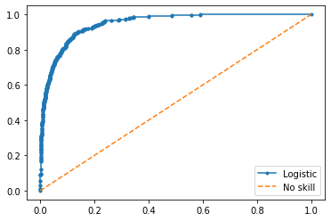

```python
fpr, tpr, thresholds = roc_curve(y_true=Default['default01'],y_score = default_prob_pred, pos_label = 1)

plt.plot(fpr, tpr, marker='.', label='Logistic')
plt.plot(tpr, tpr, linestyle='--', label='No skill')
plt.legend()
plt.show()
```

The area under the curve can be computed via roc_auc_score.

```python
roc_auc_score(y_true=Default['default01'],y_score = default_prob_pred)
```

```
0.9495581233452343
```

## KNN

```python
from sklearn.preprocessing import LabelEncoder
```

```python
le=LabelEncoder()
Default['student01'] = le.fit_transform(Default['student'])
```

```python
print(Default['student'].unique())
print(le.fit_transform(Default['student'].unique()))
```

```
['No' 'Yes']
[0 1]
```

```python
Default_train=Default.head(int(len(Default)*0.8)).reset_index(drop=True)
Default_test=Default.tail(len(Default) - int(len(Default)*0.8)).reset_index(drop=True)
Default_test.head()
```

|  | default | student | balance | income | default01 | student01 |
| --- | --- | --- | --- | --- | --- | --- |
| 0 | No | No | 304.146598 | 23866.935858 | 0 | 0 |
| 1 | No | No | 353.631131 | 40686.760148 | 0 | 0 |
| 2 | No | No | 1269.420335 | 39010.148187 | 0 | 0 |
| 3 | No | Yes | 397.542488 | 22710.865740 | 0 | 1 |
| 4 | No | No | 607.166271 | 49547.465816 | 0 | 0 |

```python
print(len(Default))
print(len(Default_test))
print(len(Default_train))
```

```
10000
2000
8000
```

```python
from sklearn.neighbors import KNeighborsClassifier
```

```python
k=11
model = KNeighborsClassifier(n_neighbors=k)
model.fit(Default_train[['balance','income','student01']],Default_train['default'])
```

```
KNeighborsClassifier(algorithm='auto', leaf_size=30, metric='minkowski',
                     metric_params=None, n_jobs=None, n_neighbors=11, p=2,
                     weights='uniform')
```

```python
Default_train['pred_label_knn']=model.predict(Default_train[['balance','income','student01']])
Default_test['pred_label_knn']=model.predict(Default_test[['balance','income','student01']])
```

We can also predict the default probability.

```python
model.predict_proba(Default_train[['balance','income','student01']])
```

```
array([[1., 0.],
       [1., 0.],
       [1., 0.],
       ...,
       [1., 0.],
       [1., 0.],
       [1., 0.]])
```

Therefore, we only use the second column to denote the default probability.

```python
Default_train['pred_prob_knn']=model.predict_proba(Default_train[['balance','income','student01']])[:,1]
Default_test['pred_prob_knn']=model.predict_proba(Default_test[['balance','income','student01']])[:,1]
```

```python
Default_train.head()
```

|  | default | student | balance | income | default01 | student01 | pred_label_knn | pred_prob_knn |
| --- | --- | --- | --- | --- | --- | --- | --- | --- |
| 0 | No | No | 729.526495 | 44361.625074 | 0 | 0 | No | 0.0 |
| 1 | No | Yes | 817.180407 | 12106.134700 | 0 | 1 | No | 0.0 |
| 2 | No | No | 1073.549164 | 31767.138947 | 0 | 0 | No | 0.0 |
| 3 | No | No | 529.250605 | 35704.493935 | 0 | 0 | No | 0.0 |
| 4 | No | No | 785.655883 | 38463.495879 | 0 | 0 | No | 0.0 |

Now we can compute the training and test performance metric as what we learn before. For instance, we can compute the training and test confusion matrix.

```python
train_cm=confusion_matrix(y_true=Default_train['default'], y_pred= Default_train['pred_label_knn'],labels=['Yes','No'])
train_cm
```

```
array([[  33,  233],
       [   9, 7725]], dtype=int64)
```

```python
test_cm=confusion_matrix(y_true=Default_test['default'], y_pred= Default_test['pred_label_knn'],labels=['Yes','No'])
test_cm
```

```
array([[   5,   62],
       [   3, 1930]], dtype=int64)
```

We can also plot the training and test ROC curve.

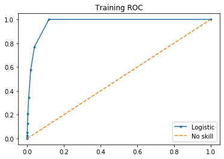

```python
fpr, tpr, thresholds = roc_curve(y_true=Default_train['default01'],y_score = Default_train['pred_prob_knn'], pos_label = 1)

plt.plot(fpr, tpr, marker='.', label='Logistic')
plt.plot(tpr, tpr, linestyle='--', label='No skill')
plt.legend()
plt.title('Training ROC')
plt.show()
```

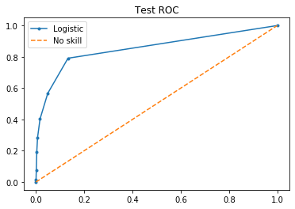

```python
fpr, tpr, thresholds = roc_curve(y_true=Default_test['default01'],y_score = Default_test['pred_prob_knn'], pos_label = 1)

plt.plot(fpr, tpr, marker='.', label='Logistic')
plt.plot(tpr, tpr, linestyle='--', label='No skill')
plt.legend()
plt.title('Test ROC')
plt.show()
```

Finish other measures on your own.

## Plot the decision boundary

We first use a small set of the data. Since default rate is too small, we use the income and balance to predict whether a person is a student.

```python
Default_small=Default.tail(int(len(Default)*0.005)).reset_index(drop=True)
Default_small_yes=Default_small[Default_small['student']=='Yes']
Default_small_no=Default_small[Default_small['student']=='No']
```

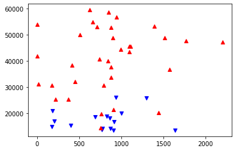

```python
plt.plot(Default_small_yes['balance'],Default_small_yes['income'],marker='v',linestyle='none',color='blue')
plt.plot(Default_small_no['balance'],Default_small_no['income'],marker='^',linestyle='none',color='red')
plt.show()
```

#### Decision boundary for logistic regression.

For logistic regression, the decision boundary appears when $$p(x) = {\exp(\beta_0 + \beta_1 x_1 + ...+ \beta_m x_m) \over 1 + \exp(\beta_0 + \beta_1 x_1+ ...+ \beta_m x_m)} = 0.5.$$ This happens when $\beta_0 + \beta_1 x_1 + ...+ \beta_m x_m = 0$.

```python
results = smf.logit('student01 ~ income+ balance', data=Default_small).fit()
print(results.summary())
```

```
Optimization terminated successfully.
         Current function value: 0.239408
         Iterations 9
                           Logit Regression Results
==============================================================================
Dep. Variable:              student01   No. Observations:                   50
Model:                          Logit   Df Residuals:                       47
Method:                           MLE   Df Model:                            2
Date:                Wed, 26 Feb 2020   Pseudo R-squ.:                  0.6181
Time:                        09:22:07   Log-Likelihood:                -11.970
converged:                       True   LL-Null:                       -31.343
Covariance Type:            nonrobust   LLR p-value:                 3.858e-09
==============================================================================
                 coef    std err          z      P>|z|      [0.025      0.975]
------------------------------------------------------------------------------
Intercept      6.3474      2.377      2.671      0.008       1.689      11.005
income        -0.0003   9.64e-05     -3.023      0.003      -0.000      -0.000
balance        0.0003      0.001      0.198      0.843      -0.002       0.003
==============================================================================
```

```python
results.params[0],results.params[1],results.params[2]
```

```
(6.34736459288108, -0.000291446973450887, 0.00026150069321136544)
```

On the bounday $$\beta_0 + \beta_{income} x_{income} + \beta_{balance} x_{balance} = 0,$$ when $x_{balance}= 0$, $income= -\beta_0/ \beta_{income}$; when $x_{balance}= 2500$, $income= -(\beta_0 + 2500\beta_{balance})/ \beta_{income}$.

Therefore, the boundary is a line that across the two points.

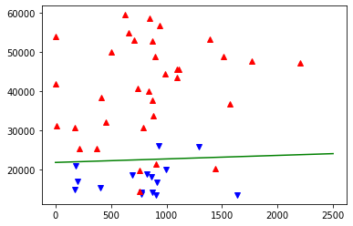

```python
plt.plot(Default_small_yes['balance'],Default_small_yes['income'],marker='v',linestyle='none',color='blue')
plt.plot(Default_small_no['balance'],Default_small_no['income'],marker='^',linestyle='none',color='red')
plt.plot([0,2500],[-results.params[0]/results.params[1],-(results.params[0]+results.params[2]*2500)/results.params[1]],color='green')
plt.show()
```

Clearly, logistic regression decision boundary is linear.

#### Decision boundary for KNN.

```python
int(min(Default_small['income'])),int(max(Default_small['income']))
```

```
(13485, 59441)
```

```python
int(min(Default_small['balance'])),int(max(Default_small['balance']))
```

```
(0, 2202)
```

```python
x = np.arange(int(min(Default_small['balance'])),int(max(Default_small['balance'])), 5)
y = np.arange(int(min(Default_small['income'])),int(max(Default_small['income'])), 150)
xx, yy = np.meshgrid(x, y)
```

Here xx,yy are the coordinates of the grid form by x and y. Here we unfold it to be

```python
xxx=xx.ravel()
yyy=yy.ravel()
```

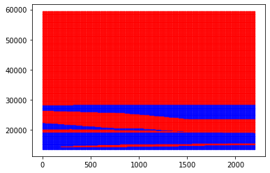

```python
k=1
model2 = KNeighborsClassifier(n_neighbors=k)
model2.fit(Default_small[['balance','income']],Default_small['student'])
Z = model2.predict(np.c_[xxx, yyy]) # raval() function unfold the matrix to a vector. np.c_ combine two vectors into a matrix
plt.scatter(xxx[Z=='Yes'],yyy[Z=='Yes'],marker='.',s=0.5,color='blue')
plt.scatter(xxx[Z=='No'],yyy[Z=='No'],marker='.',s=0.5,color='red')
plt.show()
```

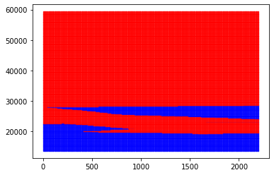

```python
k=3
model2 = KNeighborsClassifier(n_neighbors=k)
model2.fit(Default_small[['balance','income']],Default_small['student'])
Z = model2.predict(np.c_[xxx, yyy]) # raval() function unfold the matrix to a vector. np.c_ combine two vectors into a matrix
plt.scatter(xxx[Z=='Yes'],yyy[Z=='Yes'],marker='.',s=0.5,color='blue')
plt.scatter(xxx[Z=='No'],yyy[Z=='No'],marker='.',s=0.5,color='red')
plt.show()
```

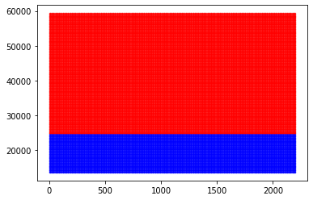

```python
k=11
model2 = KNeighborsClassifier(n_neighbors=k)
model2.fit(Default_small[['balance','income']],Default_small['student'])
Z = model2.predict(np.c_[xxx, yyy]) # raval() function unfold the matrix to a vector. np.c_ combine two vectors into a matrix
plt.scatter(xxx[Z=='Yes'],yyy[Z=='Yes'],marker='.',s=0.5,color='blue')
plt.scatter(xxx[Z=='No'],yyy[Z=='No'],marker='.',s=0.5,color='red')
plt.show()
```

Clearly, as $k$ increase, the boundary becomes more smooth.